# Human Activity Recognition

Michael Conway

Friday, August 22, 2014

# Methodology

## Summary of Data

The HAR data contained variables measuring the movement of one of 6 subjects in incremental time windows from data collected from a accelerometer, gyroscope and magnetometer. Data from these devices was used to calculate Eular angles along with the raw directional vector data [1]. These variable along with user data, time data and summary statistics like variance and standard deviation encompassed the 160 variables and roughly 39k samples generated from the experiment. About half was provided for the analysis of this report.

## Preporcessing and Feature Selection

I immediately made a 60/40 split of the data into training and testing partitions based on the ‘classe’ variable. The summary statistics were not measured in a predictable way and only 406 summaries were recorded. After seperating them out and formulating a classification model they did show predictive power, however with only 406 samples and they being a summary of other variables I decided to move forward without them.

```r
#Install packages and download data
library(plyr);library(ggplot2);library(lattice);library(knitr);library(randomForest);library(caret)
train <- read.csv(paste(getwd(), "pml-training.csv", sep="/"), header=TRUE)
test <- read.csv(paste(getwd(), "pml-testing.csv", sep="/"), header=TRUE)

#Create partition and remove unwanted variables
set.seed(33141)
inTrain <- createDataPartition(y=train$classe, p=0.60, list=FALSE)
training <- train[inTrain,]
testing <- train[-inTrain,]

tr <- training[,sapply(training, function(x) sum(is.na(x))) == 0]
ntr <- tr[,sapply(tr,class)=="numeric"]
```

```r
#Exclude un-predictive variables
ntrCor <- cor(ntr)
highCor <- findCorrelation(ntrCor, cutoff = 0.70)
ntr <- ntr[, -highCor]

ntrfinal <- ntr[, sapply(ntr, sd) > 1]
```

Logically the ‘user_name’ would have to impact the prediction of the outcome since body type and strength would impact at least two of the devices collecting data. I went ahead and converted the user names into dummy variables and appended them to the list of processed variables along with the ‘classe’ outcome variable. The idea is to improve the model, but at the very least it lowers the processing effort. Dummy variables are then appending to the ‘testing’ and ‘test’ data sets so the model can be applied.

```r
#Append outcome and dummy variables to final and dummy variables to test
dumtrain <- dummyVars(~ user_name, data=training)
userdum <- predict(dumtrain, training)
ntrfinal <- cbind(ntrfinal, userdum)
ntrfinal$classe <- training$classe
usertedum <- dummyVars(~user_name, data=testing)
ustesting <- predict(usertedum, testing)
testing <- cbind(testing, ustesting)
usertest <- dummyVars(~ user_name, data=test)
userte <- predict(usertest, newdata=test)
test <- cbind(test, userte)
```

## Model Selection

Given the results of the initial trial and error attempts before widdling down the features and the nature of the data being so variable it seems that random forest is the way to go. Also, the default settings for random forest in the ‘caret’ package took way too much time even for my core i7 and 16 gigabytes of ram; therefore I scaled back the cross-validation to 4 folds. Eureka, this did the trick where the most accurate model selected 12 features for each tree with an accuracy around 0.98 in the training sample.

```r
tc <- trainControl(method="cv", number=4, allowParallel=TRUE)
feModrf <- train(ntrfinal$classe ~ ., data=ntrfinal, method="rf", trControl=tc)
feModrf
```

```
## Random Forest
##
## 11776 samples
##    22 predictor
##     5 classes: 'A', 'B', 'C', 'D', 'E'
##
## No pre-processing
## Resampling: Cross-Validated (4 fold)
##
## Summary of sample sizes: 8832, 8831, 8832, 8833
##
## Resampling results across tuning parameters:
##
##   mtry  Accuracy  Kappa  Accuracy SD  Kappa SD
##    2    1         1      0.004        0.005
##   12    1         1      0.003        0.003
##   22    1         1      0.002        0.003
##
## Accuracy was used to select the optimal model using  the largest value.
## The final value used for the model was mtry = 12.
```

```r
fintesting <- predict(feModrf, testing)
confusionMatrix(testing$classe, fintesting)
```

```
## Confusion Matrix and Statistics
##
##           Reference
## Prediction    A    B    C    D    E
##          A 2226    2    2    0    2
##          B    7 1489   15    4    3
##          C    0    6 1349   12    1
##          D    0    1   27 1253    5
##          E    1    6    7    3 1425
##
## Overall Statistics
##
##                Accuracy : 0.987
##                  95% CI : (0.984, 0.989)
##     No Information Rate : 0.285
##     P-Value [Acc > NIR] : <2e-16
##
##                   Kappa : 0.983
##  Mcnemar's Test P-Value : NA
##
## Statistics by Class:
##
##                      Class: A Class: B Class: C Class: D Class: E
## Sensitivity             0.996    0.990    0.964    0.985    0.992
## Specificity             0.999    0.995    0.997    0.995    0.997
## Pos Pred Value          0.997    0.981    0.986    0.974    0.988
## Neg Pred Value          0.999    0.998    0.992    0.997    0.998
## Prevalence              0.285    0.192    0.178    0.162    0.183
## Detection Rate          0.284    0.190    0.172    0.160    0.182
## Detection Prevalence    0.284    0.193    0.174    0.164    0.184
## Balanced Accuracy       0.998    0.993    0.980    0.990    0.995
```

The confusion matrix shows sample error of around 1-2% on the testing set, which I think is the sweet spot since the final model developed by the researchers who performed the study came up with about the same with a similar error matrix[1]. Below are visual representation of cross-validation results and error rate relative to forest size per feature selection.

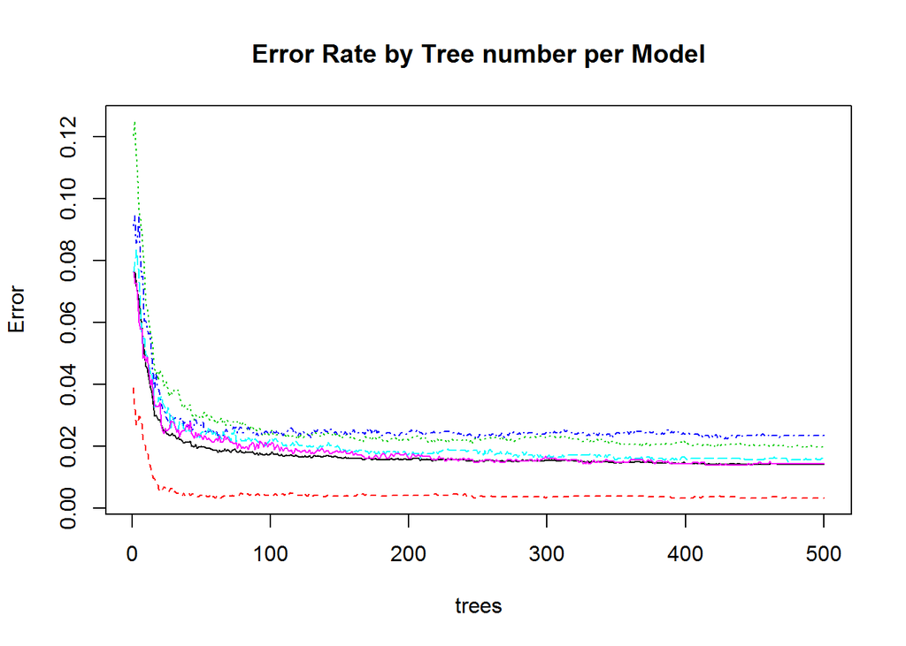

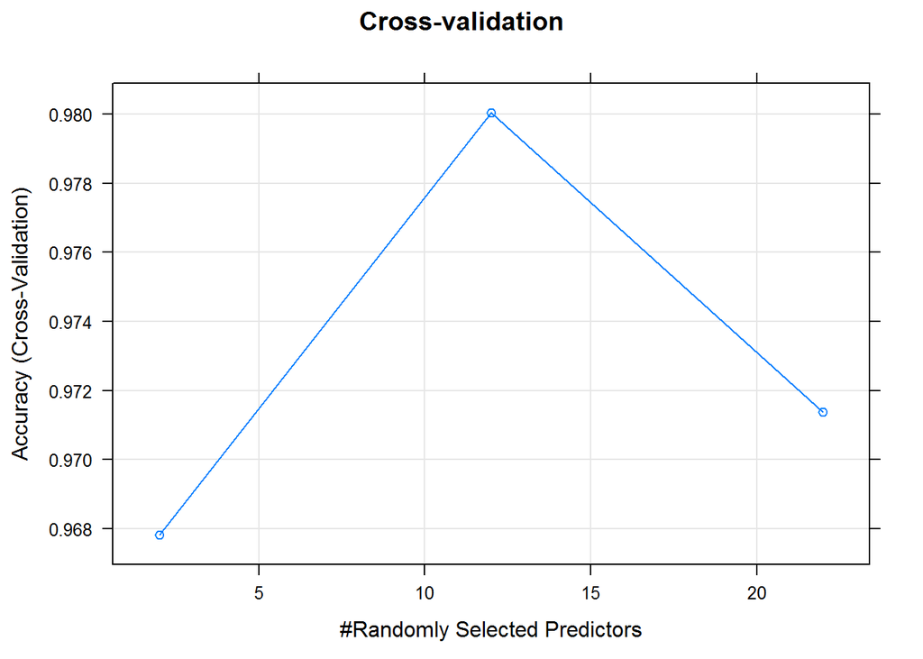

```r
plot(feModrf$finalModel, main="Error Rate by Tree number per Model");plot(feModrf, main="Cross-validation")
```

[1] Velloso, E.; Bulling, A.; Gellersen, H.; Ugulino, W.; Fuks, H. Qualitative Activity Recognition of Weight Lifting Exercises. Proceedings of 4th International Conference in Cooperation with SIGCHI (Augmented Human ’13) . Stuttgart, Germany: ACM SIGCHI, 2013.

Read more: http://groupware.les.inf.puc-rio.br/har#ixzz3BAZblNMg